```python
import numpy as np
import matplotlib.pyplot as plt
import cuqi
from cuqi.model import Model #, LinearModel
from cuqi.geometry import MappedGeometry, Continuous1D, KLExpansion #, Geometry, Continuous
from cuqi.distribution import Gaussian, JointDistribution
from cuqi.sampler import MH, NUTS
from scipy.linalg import lu_factor, lu_solve
import scipy as sp
import pickle
from utils_plotting import posterior_stats_1D
import arviz
import dill
from beam_model_1D import BeamModel1D

from plot_settings import define_plot_settings

import warnings
warnings.filterwarnings("ignore")

define_plot_settings(18)

np.random.seed(4)
run_analysis = False
```

# 1D Beam thickness estimation

[figure not shown]

The Bayesian inverse problem is to infer the second moment of inertia of the beam, $\mathbf{I}_z$, along the beam from measurements of the beam deflections, $\mathbf{u}$. This can be formulated as

$$ \mathbf{v} = G(\mathbf{I}_z) + G(\mathbf{I}_z) \times \bm{\epsilon} $$

where the forward model found by solving the finite element equations:

$$ G(\mathbf{I}_z) = \mathbf{K}(\mathbf{I}_z)^{-1} \mathbf{f} $$

The bending stiffness of the beam is a product of the Young's modulus of the material, $E$, and the second moment of area, $I$. The second moment of area of a rectangular beam is related to the beam thickness by

$$ I_z = \frac{1}{12}\,b\,t^3 $$

The relation between the beam deflection, $u$, and the external forces is given by the Euler-Bernoulli beam equation:

$$ M(v(\xi),I_z(\xi)) = -EI_z(\xi) \frac{d^2 v(\xi)}{d \xi^2} $$

To represent the second moment of area as a continuous Gaussian random function, the KL expansion is introduced as:

$$ \mathbf{X} = \mu_t + \sigma \sum_{i=1}^{N_{KL}} Z_i \sqrt{\lambda_i} \mathbf{e}_i $$

where the second moment of area can be extracted as $\mathbf{I}_z = \exp({\mathbf{X}})$ to avoid negative second moment of area.

This transforms the Bayesian inverse problem to instead being a problem of inferring the coefficients, $Z_i$, i.e.

$$ \mathbf{v} = G(\mathbf{I}_z(Z_i)) + G(\mathbf{I}_z(Z_i)) \times \bm{\epsilon} $$

The noise is assummed Gaussian i.i.d.

$$ \bm{\epsilon} \sim \mathcal{N}(0, \sigma_{obs}^2 \mathbf{I}) $$

The likelihood function is obtained from the forward model as

$$\pi(v_{obs}|Z_i) \sim \mathcal{N}(G(\mathbf{I}_z (Z_i), G(\mathbf{I}_z(Z_i))^2 \sigma_{obs}^2 \mathbf{I})$$

Set-up model in CUQI

```python
# Data and initialization
IZ = lambda X: np.exp(X)            # Define mapping
L = 100                             # Domain length
N_points = 99                       # Number of discretization points
nelx = N_points                     # No. of beam elements
N_KL = 10                           # Number of terms in KL expansion
grid = np.linspace(0,L,N_points)    # Discretization for domain

# Create 1D beam model
beam = BeamModel1D(nelx=nelx, L=L)
model_Beam = Model(forward=beam.forward,
                   range_geometry=Continuous1D(grid=grid),
                   domain_geometry=MappedGeometry(KLExpansion(grid=grid,
                                                              num_modes=N_KL,
                                                              decay_rate=2),
                                                              map=IZ))

# Gaussian prior: thkVec -> test it on beam domain (on Zs in KL expansion)
sigma_pr = 5
prior = Gaussian(0, sigma_pr**2, geometry=model_Beam.domain_geometry, name='Iz')

# def create_matrix(n):
#     matrix = np.zeros((n, n))
#     for i in range(n):
#         for j in range(n):
#             matrix[i, j] = (1 - ( abs(i - j)/n )*np.max(n/4.-abs(i-j),0) )**2
#     return matrix
# cov = create_matrix(N_points)
# cov = sp.sparse.diags(np.array([0.1, 0.25, 1, 0.25, 0.1]),
#                       np.array([-2, -1, 0, 1, 2]), shape=(N_points, N_points))
```

Generate true signal:

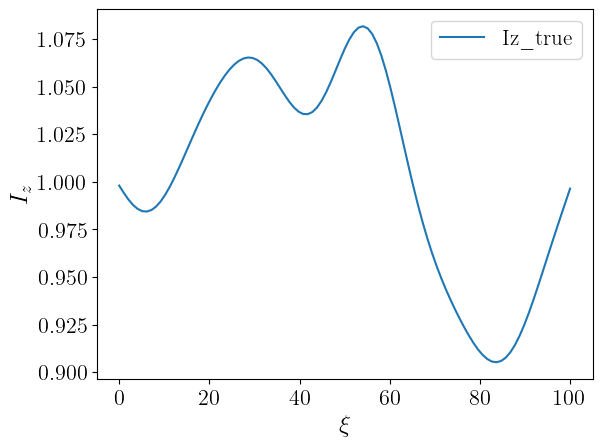

```python
# from cProfile import label

Zs_true = prior.sample(1)
Iz_true = Zs_true.funvals                # True beam thickness
v_true = beam.forward(Iz_true)           # True beam deflection

# Iz_true.plot()
plt.plot(grid, Iz_true,label="Iz_true");
plt.xlabel('$\\xi$');
plt.ylabel('$I_z$');
plt.legend();
```

#### Generate the likelihood functions

```python
sigma_obs = 0.05 # 0.05

# Creating the covariance matrix
ell = 0.01*L
Gaussian_kernel = lambda xi1,xi2: \
    np.exp( -(xi1 - xi2)**2/(2*ell**2) ) # complete the lambda function for the Gaussian Kernel

cov = np.zeros([N_points, N_points])
for i in range(N_points):
    for j in range(N_points):
        cov[i,j] = Gaussian_kernel(grid[i], grid[j])

def cov_like(Iz):
    fx = model_Beam(Iz)
    cov_mat = sigma_obs**2*fx**2*np.identity(N_points) #*cov
    return cov_mat

# Gaussian Likelihood: v
likelihood = cuqi.distribution.Gaussian(mean=model_Beam,
                                        cov=cov_like,
                                        name='v')
likelihood2 = cuqi.distribution.Gaussian(mean=model_Beam,
                                        cov=cov_like,
                                        name='v2')
likelihood3 = cuqi.distribution.Gaussian(mean=model_Beam,
                                        cov=cov_like,
                                        name='v3')
likelihood4 = cuqi.distribution.Gaussian(mean=model_Beam,
                                        cov=cov_like,
                                        name='v4')
likelihood5 = cuqi.distribution.Gaussian(mean=model_Beam,
                                        cov=cov_like,
                                        name='v5')
# print(model_Beam.range_geometry)
# print(model_Beam.domain_geometry)

# plt.spy(cov_like(Iz_true));
# print(np.min(np.linalg.eigvals(cov_like(Iz_true))))
model_Beam
```

```
CUQI Model: MappedGeometry(KLExpansion(10,)) -> Continuous1D(99,).
    Forward parameters: ['Iz'].
```

Create synthetic measurement data. This is acheived by obtaining first computing 'true' signal by sampling from the prior and running forward model. Then, the measurement data is obtained by adding noise to the 'true' signal.

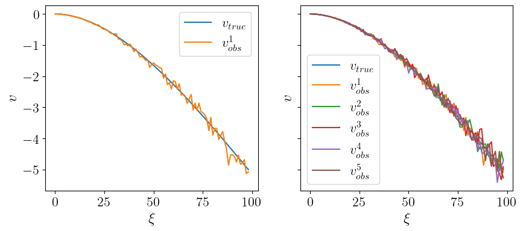

```python
# Obtain measurement data by adding noise #TODO: Fix INVERSE CRIME
# v_obs = v_true + epsilon
np.random.seed(3)
v_obs  = likelihood(Iz=Iz_true).sample()
v_obs2 = likelihood2(Iz=Iz_true).sample()
v_obs3 = likelihood3(Iz=Iz_true).sample()
v_obs4 = likelihood4(Iz=Iz_true).sample()
v_obs5 = likelihood5(Iz=Iz_true).sample()

fig, ax = plt.subplots(1,2,figsize=(10,4),sharey=True)
plt.sca(ax[0])
# Plot true and measurement data together with likelihood function at t=t_true
plt.plot(v_true, label='$v_{true}$')
plt.plot(v_obs, label='$v_{obs}^1$')
plt.xlabel('$\\xi$')
plt.ylabel('$v$')
plt.legend();
plt.sca(ax[1])
plt.plot(v_true, label='$v_{true}$')
plt.plot(v_obs, label='$v_{obs}^1$')
plt.plot(v_obs2, label='$v_{obs}^2$')
plt.plot(v_obs3, label='$v_{obs}^3$')
plt.plot(v_obs4, label='$v_{obs}^4$')
plt.plot(v_obs5, label='$v_{obs}^5$')
# likelihood(Iz=Iz_true).sample(1).plot(label='$v_{like}(I_z=I_{z,{true}})$')
plt.xlabel('$\\xi$')
plt.ylabel('$v$')
plt.legend();
```

Define posterior model

```python
joint_5 = JointDistribution(likelihood,likelihood2,likelihood3,likelihood4,likelihood5,prior)
print(joint_5)
posterior_5 = joint_5(v=v_obs,v2=v_obs2,v3=v_obs3,v4=v_obs4,v5=v_obs5)

joint = JointDistribution(likelihood,prior)
print(joint)
posterior = joint(v=v_obs)

# print(v_obs.shape)
# print(posterior)
# posterior.geometry

pickle_path = 'Zs_MAP.pickle'
if 1:
    Zs_opt = cuqi.problem.BayesianProblem(likelihood, prior).set_data(v=v_obs)
    print(Zs_opt)
    Zs_MAP = Zs_opt.MAP()
    with open(pickle_path, 'wb') as handle:
        pickle.dump(Zs_MAP, handle, protocol=pickle.HIGHEST_PROTOCOL)
else:
    with open(pickle_path, 'rb') as pf:
        Zs_MAP = pickle.load(pf)
```

```
JointDistribution(
    Equation:
	p(v,v2,v3,v4,v5,Iz) = p(v|Iz)p(v2|Iz)p(v3|Iz)p(v4|Iz)p(v5|Iz)p(Iz)
    Densities:
	v ~ CUQI Gaussian. Conditioning variables ['Iz'].
	v2 ~ CUQI Gaussian. Conditioning variables ['Iz'].
	v3 ~ CUQI Gaussian. Conditioning variables ['Iz'].
	v4 ~ CUQI Gaussian. Conditioning variables ['Iz'].
	v5 ~ CUQI Gaussian. Conditioning variables ['Iz'].
	Iz ~ CUQI Gaussian.
)
JointDistribution(
    Equation:
	p(v,Iz) = p(v|Iz)p(Iz)
    Densities:
	v ~ CUQI Gaussian. Conditioning variables ['Iz'].
	Iz ~ CUQI Gaussian.
)
BayesianProblem with target:
 Posterior(
    Equation:
	 p(Iz|v) ∝ L(Iz|v)p(Iz)
    Densities:
	v ~ CUQI Gaussian Likelihood function. Parameters ['Iz'].
 	Iz ~ CUQI Gaussian.
 )
!!!!!!!!!!!!!!!!!!!!!!!!!!!!!!!!!!!!!!!!!!!!!!!!!!!
!!! Automatic solver selection is experimental. !!!
!!!    Always validate the computed results.    !!!
!!!!!!!!!!!!!!!!!!!!!!!!!!!!!!!!!!!!!!!!!!!!!!!!!!!

Optimizing with approximate gradients.
Using scipy.optimize.minimize on negative log of Posterior
x0: ones vector
```

Sample using the Metropolis-Hastings sampler

```python
np.random.seed(8)
pickle_path = 'samples_MH.pickle'
if 1:
    Ns = 10000 #int(50e3)
    Z0 = Zs_MAP.to_numpy()
    sampler_MH_5 = MH(posterior_5, x0=Z0, scale=0.5)
    samples_MH_5 = sampler_MH_5.sample_adapt(Ns)

    sampler_MH = MH(posterior, x0=Z0, scale=1)
    samples_MH = sampler_MH.sample_adapt(Ns)

    # samples_MH.pickle()
    # res = {}
    # res['samples'] = samples_MH.samples
    # res['samples_funvals'] = samples_MH.funvals.samples
    # with open(pickle_path, 'wb') as handle:
    #     pickle.dump(sampler_MH, handle, protocol=pickle.HIGHEST_PROTOCOL)
else:
    pass
    # with open(pickle_path, 'rb') as pf:
    #     res = pickle.load(pf)
    # samples_MH_samples = res['samples']
    # samples_MH_samples_funvals = res['samples_funvals']
```

```
Sample 10000 / 10000

Average acceptance rate: 0.225 MCMC scale: 0.4836991951185264

Sample 10000 / 10000

Average acceptance rate: 0.2344 MCMC scale: 0.9980303587862059
```

Sample using the No-U-turn sampler (NUTS)

```python
if 1:
    Ns = 20
    posterior.enable_FD()
    sampler_NUTS = NUTS(posterior, x0=Zs_MAP.to_numpy())
    samples_NUTS = sampler_NUTS.sample(Ns, Nb=5)
```

```
Sample 25 / 25
```

Compute effective sample sizes

```python
print(samples_MH.compute_ess())
print(samples_NUTS.compute_ess())
```

```
[18.37842735 19.17104311 18.65695569  5.86636718  2.77197597  3.90478212
  3.7093092   1.63505086  9.48727747  4.77052858]
[26.02059991 14.8184966  11.67445826 13.74913955 26.02059991  9.2984742
  7.29099312 16.55207854 24.37380658 18.34339381]
```

```python
# dill_path = 'samples_NUTS.dill'
# if 0:
#     Ns = 5
#     posterior.enable_FD()
#     sampler_NUTS = NUTS(posterior, x0=Zs_MAP.to_numpy())
#     samples_NUTS = sampler_NUTS.sample(Ns, Nb=1)

#     with open(dill_path, 'wb') as handle:
#         dill.dump(samples_NUTS, handle, protocol=pickle.HIGHEST_PROTOCOL)
# else:
#     with open(dill_path, 'rb') as pf:
#         samples_NUTS = dill.load(pf)
```

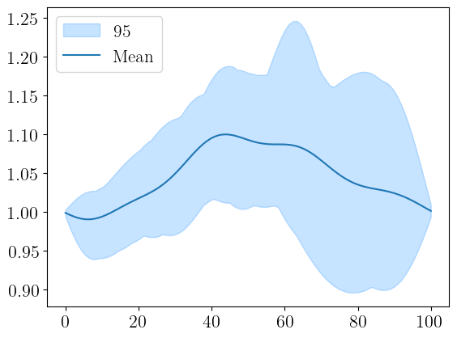

```python
samples_NUTS.funvals.plot_ci();
```

Plot credible intervals

```
arviz - WARNING - Shape validation failed: input_shape: (1, 10000), minimum_shape: (chains=2, draws=4)
```

```
    mean     sd  hdi_3%  hdi_97%  mcse_mean  mcse_sd  ess_bulk  ess_tail  \
x  0.078  3.801  -7.187    6.493        0.6    0.427      40.0     106.0

   r_hat
x    NaN
```

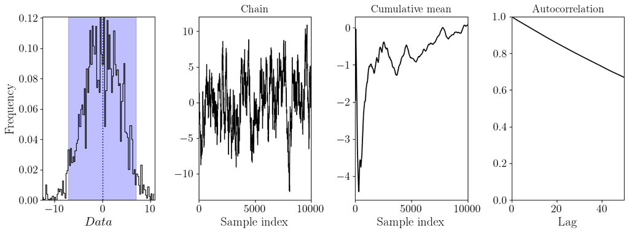

```
arviz - WARNING - Shape validation failed: input_shape: (1, 450), minimum_shape: (chains=2, draws=4)
```

```
    mean    sd  hdi_3%  hdi_97%  mcse_mean  mcse_sd  ess_bulk  ess_tail  r_hat
x  0.228  3.82  -6.823    6.901      0.649    0.463      35.0      80.0    NaN
```

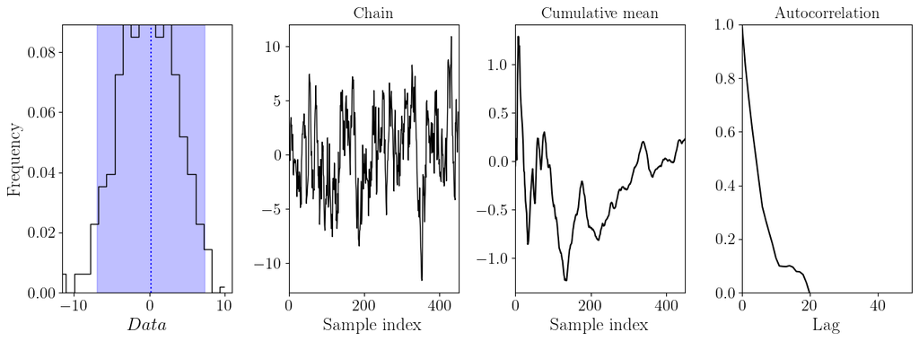

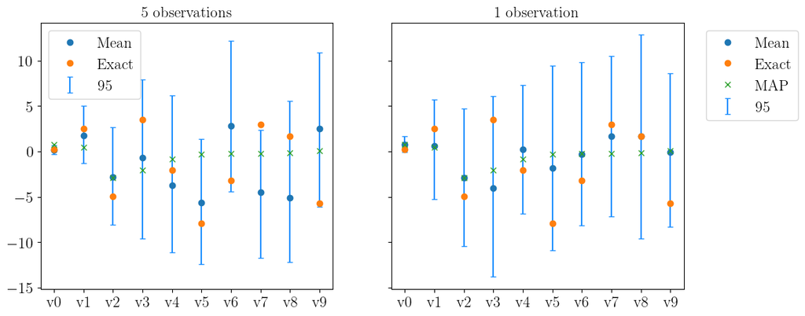

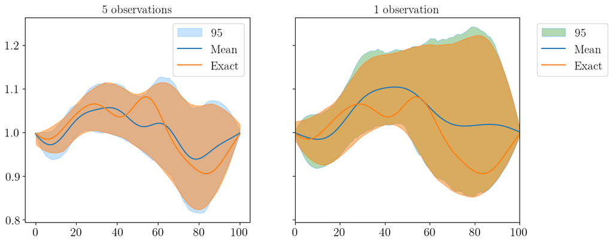

```python
from cProfile import label
from turtle import position

from matplotlib.figure import figaspect


Nb = 1000 #int(10e3)
Nt = int(20)
bt_samples_MH_5 = samples_MH_5.burnthin(Nb, Nt)
bt_samples_MH = samples_MH.burnthin(Nb, Nt)

posterior_stats_1D(samples_MH.samples[4,:])
posterior_stats_1D(bt_samples_MH.samples[4,:])
plt.show()

fig, ax = plt.subplots(1,2,figsize=(12, 5),sharey=True)
plt.sca(ax[0])
bt_samples_MH_5.plot_ci(plot_par=True, exact=Zs_true)
plt.plot(Zs_MAP, 'x', label='MAP')
plt.title('5 observations')
plt.sca(ax[1])
bt_samples_MH.plot_ci(plot_par=True, exact=Zs_true)
plt.title('1 observation')
# samples_NUTS.plot_ci(plot_par=True,exact=Zs_true)
plt.plot(Zs_MAP, 'x', label='MAP')

plt.legend(bbox_to_anchor=(1.05, 1), loc='upper left')

fig, ax = plt.subplots(1,2,figsize=(12, 5),sharey=True)
plt.sca(ax[0])
bt_samples_MH_5.funvals.plot_ci(plot_par=False, exact=Iz_true);#, color='k');
arviz.plot_hdi(grid, samples_MH_5.funvals.samples.T, hdi_prob=0.95);
plt.title('5 observations')

plt.sca(ax[1])
bt_samples_MH.funvals.plot_ci(plot_par=False, exact=Iz_true, plot_envelope_kwargs={'facecolor':'green','alpha':0.3});
arviz.plot_hdi(grid, samples_MH.funvals.samples.T, hdi_prob=0.95)
plt.title('1 observation')
# plt.figure();

bt_samples = bt_samples_MH_5.funvals.samples.T


plt.xlim([0, 100])
# plt.ylim([0, 1.25])
plt.legend(bbox_to_anchor=(1.05, 1), loc='upper left')
plt.show()


# samples_NUTS.plot_ci(plot_par=False,exact=Zs_true)

# lower, upper = np.percentile(samples, [2.5, 97.5], axis=0)
# plt.fill_between(grid,
#                 lower,
#                 upper,
#                 color='red',
#                 label=r'95\% CI',
#                 alpha=0.25)
```

Plot trace for a specific variable

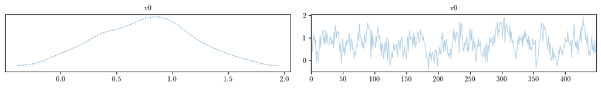

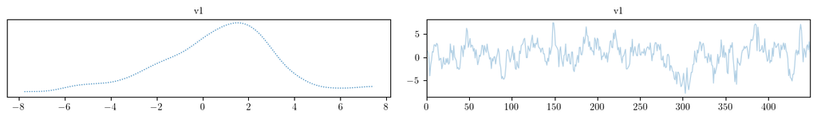

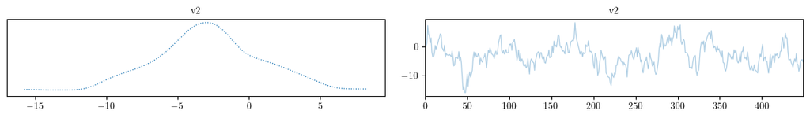

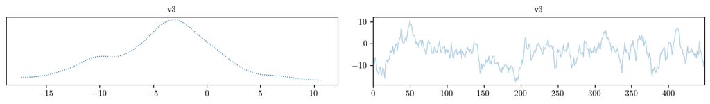

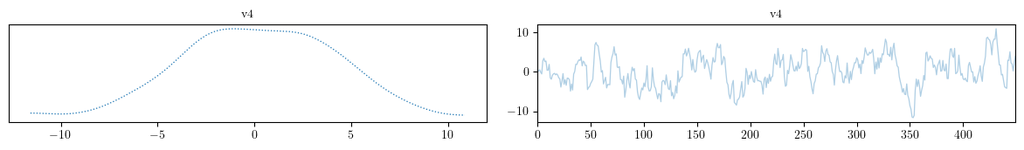

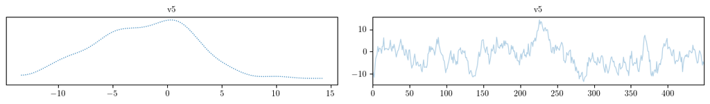

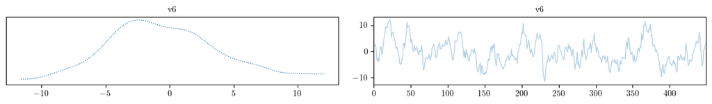

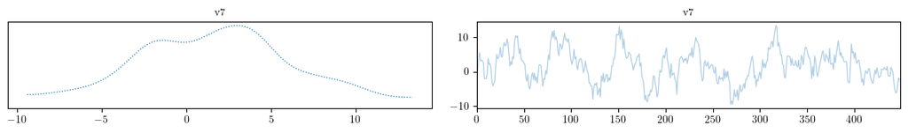

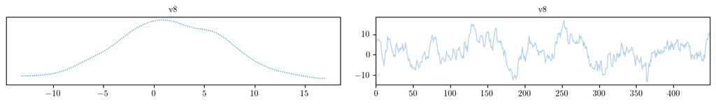

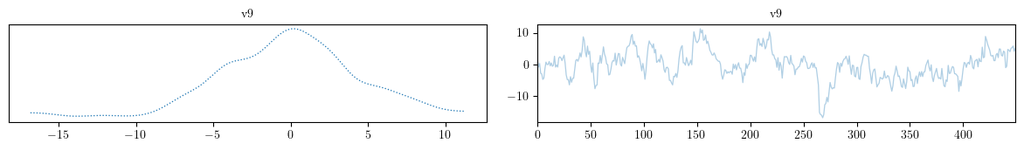

```python
# define_plot_settings(10)
for i in range(N_KL):
    bt_samples_MH.plot_trace([i]);
# samples_NUTS.plot_trace([3])
# samples_MH.plot_autocorrelation()
```

```
Selecting 5 randomly chosen variables
```

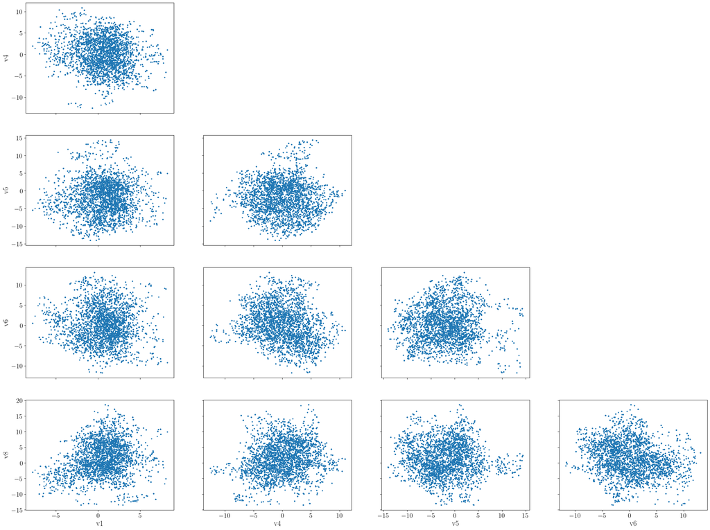

```python
samples_MH.plot_pair();
```

```python
sampler_NUTS.num_tree_node_list
```

```
[89,
 1,
 1,
 120,
 120,
 502,
 120,
 120,
 120,
 120,
 120,
 57,
 57,
 57,
 57,
 120,
 120,
 120,
 120,
 120,
 120,
 42,
 57,
 120]
```

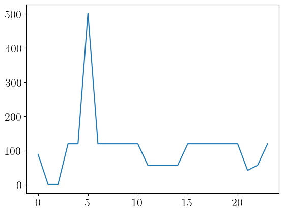

```python
plt.plot(sampler_NUTS.num_tree_node_list);
```

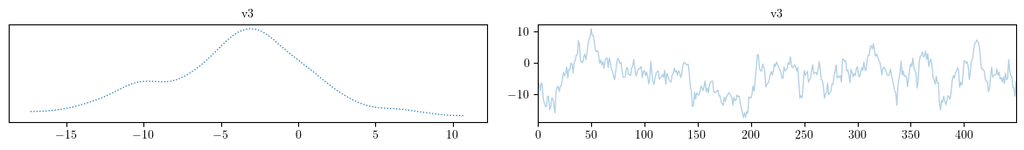

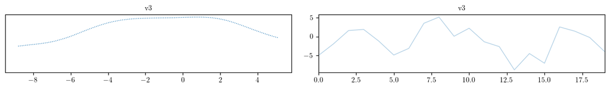

```python
bt_samples_MH.plot_trace([3]);
samples_NUTS.plot_trace([3]);
```

### Analytical model:

The relation between the beam deflection, $u$, and the external forces is given by the Euler-Bernoulli beam equation:

$$ M(v(\xi)) = -EI(\xi) \frac{d^2 v(\xi)}{d \xi^2} $$

The bending stiffness of the beam is a product of the Young's modulus of the material, $E$, and the second moment of area, $I$. The second moment of area of a rectangular beam is related to the beam thickness by

$$ I_z = \frac{1}{12}bt^3 $$

The moment distribution for the tip load is found as

$$ M(x) = -P(L - x) $$

Thus, the beam deflection can be found by solving the beam equation:

$$\frac{d^2 v(x)}{d x^2} = \frac{P}{EI(x)}(L - x) $$